# Risk Factor Analysis

## Outcome Variable

**Outcome Variable:** whz

## Predictor Variables

**Intervention Variable:** impsan

**Adjustment Set:**

- arm
- sex
- W_mage
- meducyrs
- feducyrs
- hhwealth_quart
- hfoodsec
- W_mhtcm
- W_mwtkg
- W_mbmi
- W_nrooms
- W_nchldlt5
- W_parity
- impfloor
- safeh20
- delta_W_mage
- delta_meducyrs
- delta_feducyrs
- delta_hhwealth_quart
- delta_hfoodsec
- delta_W_mhtcm
- delta_W_mwtkg
- delta_W_mbmi
- delta_W_nrooms
- delta_W_nchldlt5
- delta_W_parity
- delta_impfloor
- delta_safeh20

## Stratifying Variables

The analysis was stratified on these variable(s):

- agecat
- studyid
- country

## Data Summary

| agecat | studyid | country | impsan | n_cell | n | outcome_variable |
| --- | --- | --- | --- | --- | --- | --- |
| Birth | COHORTS | GUATEMALA | 1 | 43 | 449 | whz |
| Birth | COHORTS | GUATEMALA | 0 | 406 | 449 | whz |
| Birth | COHORTS | INDIA | 1 | 1685 | 4461 | whz |
| Birth | COHORTS | INDIA | 0 | 2776 | 4461 | whz |
| Birth | COHORTS | PHILIPPINES | 1 | 177 | 1126 | whz |
| Birth | COHORTS | PHILIPPINES | 0 | 949 | 1126 | whz |
| Birth | CONTENT | PERU | 1 | 1 | 2 | whz |
| Birth | CONTENT | PERU | 0 | 1 | 2 | whz |
| Birth | JiVitA-3 | BANGLADESH | 1 | 12413 | 17991 | whz |
| Birth | JiVitA-3 | BANGLADESH | 0 | 5578 | 17991 | whz |
| Birth | JiVitA-4 | BANGLADESH | 1 | 1859 | 2394 | whz |
| Birth | JiVitA-4 | BANGLADESH | 0 | 535 | 2394 | whz |
| Birth | MAL-ED | BANGLADESH | 1 | 168 | 201 | whz |
| Birth | MAL-ED | BANGLADESH | 0 | 33 | 201 | whz |
| Birth | MAL-ED | BRAZIL | 1 | 56 | 57 | whz |
| Birth | MAL-ED | BRAZIL | 0 | 1 | 57 | whz |
| Birth | MAL-ED | INDIA | 1 | 14 | 39 | whz |
| Birth | MAL-ED | INDIA | 0 | 25 | 39 | whz |
| Birth | MAL-ED | NEPAL | 1 | 24 | 25 | whz |
| Birth | MAL-ED | NEPAL | 0 | 1 | 25 | whz |
| Birth | MAL-ED | PERU | 1 | 50 | 203 | whz |
| Birth | MAL-ED | PERU | 0 | 153 | 203 | whz |
| Birth | MAL-ED | SOUTH AFRICA | 1 | 0 | 94 | whz |
| Birth | MAL-ED | SOUTH AFRICA | 0 | 94 | 94 | whz |
| Birth | MAL-ED | TANZANIA, UNITED REPUBLIC OF | 1 | 0 | 110 | whz |
| Birth | MAL-ED | TANZANIA, UNITED REPUBLIC OF | 0 | 110 | 110 | whz |
| Birth | NIH-Birth | BANGLADESH | 1 | 222 | 575 | whz |
| Birth | NIH-Birth | BANGLADESH | 0 | 353 | 575 | whz |
| Birth | NIH-Crypto | BANGLADESH | 1 | 610 | 696 | whz |
| Birth | NIH-Crypto | BANGLADESH | 0 | 86 | 696 | whz |

[output cut: 70 more lines]

The following strata were considered:

- agecat: 24 months, studyid: COHORTS, country: GUATEMALA
- agecat: 24 months, studyid: COHORTS, country: INDIA
- agecat: 24 months, studyid: COHORTS, country: PHILIPPINES
- agecat: 24 months, studyid: CONTENT, country: PERU
- agecat: 24 months, studyid: JiVitA-3, country: BANGLADESH
- agecat: 24 months, studyid: JiVitA-4, country: BANGLADESH
- agecat: 24 months, studyid: LCNI-5, country: MALAWI
- agecat: 24 months, studyid: MAL-ED, country: BANGLADESH
- agecat: 24 months, studyid: MAL-ED, country: BRAZIL
- agecat: 24 months, studyid: MAL-ED, country: INDIA
- agecat: 24 months, studyid: MAL-ED, country: NEPAL
- agecat: 24 months, studyid: MAL-ED, country: PERU
- agecat: 24 months, studyid: MAL-ED, country: SOUTH AFRICA
- agecat: 24 months, studyid: MAL-ED, country: TANZANIA, UNITED REPUBLIC OF
- agecat: 24 months, studyid: NIH-Birth, country: BANGLADESH
- agecat: 24 months, studyid: NIH-Crypto, country: BANGLADESH
- agecat: 24 months, studyid: PROVIDE, country: BANGLADESH
- agecat: 6 months, studyid: COHORTS, country: GUATEMALA
- agecat: 6 months, studyid: COHORTS, country: INDIA
- agecat: 6 months, studyid: COHORTS, country: PHILIPPINES
- agecat: 6 months, studyid: CONTENT, country: PERU
- agecat: 6 months, studyid: JiVitA-3, country: BANGLADESH
- agecat: 6 months, studyid: JiVitA-4, country: BANGLADESH
- agecat: 6 months, studyid: LCNI-5, country: MALAWI
- agecat: 6 months, studyid: MAL-ED, country: BANGLADESH
- agecat: 6 months, studyid: MAL-ED, country: BRAZIL
- agecat: 6 months, studyid: MAL-ED, country: INDIA
- agecat: 6 months, studyid: MAL-ED, country: NEPAL
- agecat: 6 months, studyid: MAL-ED, country: PERU
- agecat: 6 months, studyid: MAL-ED, country: SOUTH AFRICA
- agecat: 6 months, studyid: MAL-ED, country: TANZANIA, UNITED REPUBLIC OF
- agecat: 6 months, studyid: NIH-Birth, country: BANGLADESH
- agecat: 6 months, studyid: NIH-Crypto, country: BANGLADESH
- agecat: 6 months, studyid: PROVIDE, country: BANGLADESH
- agecat: Birth, studyid: COHORTS, country: GUATEMALA
- agecat: Birth, studyid: COHORTS, country: INDIA
- agecat: Birth, studyid: COHORTS, country: PHILIPPINES
- agecat: Birth, studyid: CONTENT, country: PERU
- agecat: Birth, studyid: JiVitA-3, country: BANGLADESH
- agecat: Birth, studyid: JiVitA-4, country: BANGLADESH
- agecat: Birth, studyid: MAL-ED, country: BANGLADESH
- agecat: Birth, studyid: MAL-ED, country: BRAZIL
- agecat: Birth, studyid: MAL-ED, country: INDIA
- agecat: Birth, studyid: MAL-ED, country: NEPAL
- agecat: Birth, studyid: MAL-ED, country: PERU
- agecat: Birth, studyid: MAL-ED, country: SOUTH AFRICA
- agecat: Birth, studyid: MAL-ED, country: TANZANIA, UNITED REPUBLIC OF
- agecat: Birth, studyid: NIH-Birth, country: BANGLADESH
- agecat: Birth, studyid: NIH-Crypto, country: BANGLADESH
- agecat: Birth, studyid: PROVIDE, country: BANGLADESH

### Dropped Strata

Some strata were dropped due to rare outcomes:

- agecat: Birth, studyid: CONTENT, country: PERU
- agecat: Birth, studyid: MAL-ED, country: BRAZIL
- agecat: Birth, studyid: MAL-ED, country: NEPAL
- agecat: Birth, studyid: MAL-ED, country: SOUTH AFRICA
- agecat: Birth, studyid: MAL-ED, country: TANZANIA, UNITED REPUBLIC OF
- agecat: Birth, studyid: PROVIDE, country: BANGLADESH
- agecat: 6 months, studyid: LCNI-5, country: MALAWI
- agecat: 6 months, studyid: MAL-ED, country: BRAZIL
- agecat: 6 months, studyid: MAL-ED, country: NEPAL
- agecat: 6 months, studyid: MAL-ED, country: SOUTH AFRICA
- agecat: 6 months, studyid: MAL-ED, country: TANZANIA, UNITED REPUBLIC OF
- agecat: 6 months, studyid: PROVIDE, country: BANGLADESH
- agecat: 24 months, studyid: LCNI-5, country: MALAWI
- agecat: 24 months, studyid: MAL-ED, country: BRAZIL
- agecat: 24 months, studyid: MAL-ED, country: NEPAL
- agecat: 24 months, studyid: MAL-ED, country: SOUTH AFRICA
- agecat: 24 months, studyid: MAL-ED, country: TANZANIA, UNITED REPUBLIC OF
- agecat: 24 months, studyid: PROVIDE, country: BANGLADESH

## Methods Detail

We’re interested in the causal parameters $E[Y_a]$ for all values of $a \in \mathcal{A}$. These parameters represent the mean outcome if, possibly contrary to fact, we intervened to set all units to have $A=a$. Under the randomization and positivity assumptions, these are identified by the statistical parameters $\psi_a=E_W[E_{Y|A,W}(Y|A=a,W)]$. In addition, we’re interested in the mean of $Y$, $E[Y]$ under no intervention (the observed mean). We will estimate these parameters by using SuperLearner to fit the relevant likelihood factors – $E_{Y|A,W}(Y|A=a,W)$ and $p(A=a|W)$, and then updating our likelihood fit using a joint TMLE.

For unadjusted analyses ($W=\{\}$), initial likelihoods were estimated using Lrnr_glm to estimate the simple $E(Y|A)$ and Lrnr_mean to estimate $p(A)$. For adjusted analyses, a small library containing Lrnr_glmnet, Lrnr_xgboost, and Lrnr_mean was used.

Having estimated these parameters, we will then use the delta method to estimate relative risks and attributable risks relative to a prespecified baseline level of $A$.

# Results Detail

## Results Plots

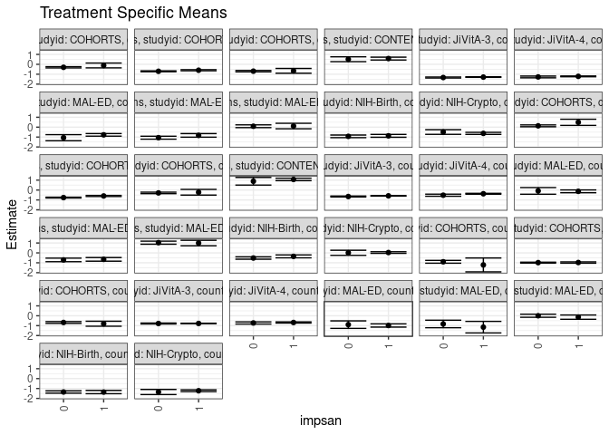

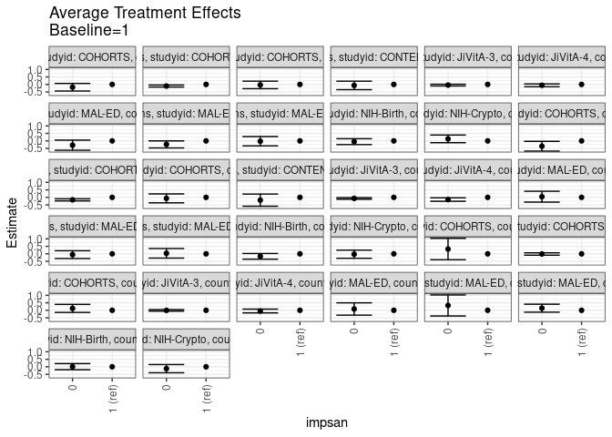

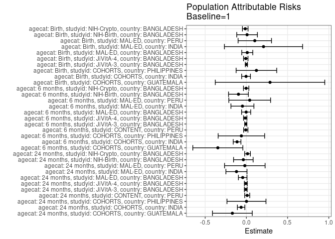

## Results Table

### Parameter: TSM

| agecat | studyid | country | intervention_level | baseline_level | estimate | ci_lower | ci_upper |
| --- | --- | --- | --- | --- | --- | --- | --- |
| Birth | COHORTS | GUATEMALA | 1 | NA | -1.2162990 | -1.9179295 | -0.5146684 |
| Birth | COHORTS | GUATEMALA | 0 | NA | -0.8976642 | -1.0419729 | -0.7533555 |
| Birth | COHORTS | INDIA | 1 | NA | -0.9733838 | -1.0384480 | -0.9083197 |
| Birth | COHORTS | INDIA | 0 | NA | -0.9840068 | -1.0289192 | -0.9390944 |
| Birth | COHORTS | PHILIPPINES | 1 | NA | -0.8059552 | -1.0579489 | -0.5539614 |
| Birth | COHORTS | PHILIPPINES | 0 | NA | -0.6786834 | -0.7691824 | -0.5881845 |
| Birth | JiVitA-3 | BANGLADESH | 1 | NA | -0.7781711 | -0.8024738 | -0.7538684 |
| Birth | JiVitA-3 | BANGLADESH | 0 | NA | -0.7823915 | -0.8307995 | -0.7339835 |
| Birth | JiVitA-4 | BANGLADESH | 1 | NA | -0.6810076 | -0.7400797 | -0.6219356 |
| Birth | JiVitA-4 | BANGLADESH | 0 | NA | -0.7271341 | -0.8381161 | -0.6161522 |
| Birth | MAL-ED | BANGLADESH | 1 | NA | -0.9837897 | -1.1460847 | -0.8214946 |
| Birth | MAL-ED | BANGLADESH | 0 | NA | -0.8970496 | -1.2757503 | -0.5183488 |
| Birth | MAL-ED | INDIA | 1 | NA | -1.1519703 | -1.7340151 | -0.5699256 |
| Birth | MAL-ED | INDIA | 0 | NA | -0.8283471 | -1.2106335 | -0.4460606 |
| Birth | MAL-ED | PERU | 1 | NA | -0.1402344 | -0.3577994 | 0.0773305 |
| Birth | MAL-ED | PERU | 0 | NA | 0.0000150 | -0.1554019 | 0.1554320 |
| Birth | NIH-Birth | BANGLADESH | 1 | NA | -1.3585088 | -1.5236968 | -1.1933209 |
| Birth | NIH-Birth | BANGLADESH | 0 | NA | -1.3513233 | -1.4681160 | -1.2345306 |
| Birth | NIH-Crypto | BANGLADESH | 1 | NA | -1.2265419 | -1.3159504 | -1.1371333 |
| Birth | NIH-Crypto | BANGLADESH | 0 | NA | -1.3528291 | -1.6117497 | -1.0939086 |
| 6 months | COHORTS | GUATEMALA | 1 | NA | 0.4921642 | 0.1813523 | 0.8029761 |
| 6 months | COHORTS | GUATEMALA | 0 | NA | 0.1365030 | 0.0422822 | 0.2307238 |
| 6 months | COHORTS | INDIA | 1 | NA | -0.5976700 | -0.6534819 | -0.5418580 |
| 6 months | COHORTS | INDIA | 0 | NA | -0.7630291 | -0.8061644 | -0.7198938 |
| 6 months | COHORTS | PHILIPPINES | 1 | NA | -0.2225785 | -0.5100638 | 0.0649068 |
| 6 months | COHORTS | PHILIPPINES | 0 | NA | -0.2904681 | -0.3668217 | -0.2141145 |
| 6 months | CONTENT | PERU | 1 | NA | 1.0715416 | 0.9485991 | 1.1944841 |
| 6 months | CONTENT | PERU | 0 | NA | 0.8857963 | 0.4994758 | 1.2721168 |
| 6 months | JiVitA-3 | BANGLADESH | 1 | NA | -0.5861838 | -0.6103314 | -0.5620362 |
| 6 months | JiVitA-3 | BANGLADESH | 0 | NA | -0.6547531 | -0.7038971 | -0.6056091 |
| 6 months | JiVitA-4 | BANGLADESH | 1 | NA | -0.3765153 | -0.4188733 | -0.3341574 |
| 6 months | JiVitA-4 | BANGLADESH | 0 | NA | -0.5225247 | -0.6303216 | -0.4147278 |
| 6 months | MAL-ED | BANGLADESH | 1 | NA | -0.1306891 | -0.2715151 | 0.0101369 |
| 6 months | MAL-ED | BANGLADESH | 0 | NA | -0.0859949 | -0.4205963 | 0.2486066 |
| 6 months | MAL-ED | INDIA | 1 | NA | -0.6541935 | -0.8379961 | -0.4703908 |
| 6 months | MAL-ED | INDIA | 0 | NA | -0.7086015 | -0.8876974 | -0.5295056 |
| 6 months | MAL-ED | PERU | 1 | NA | 0.9969706 | 0.7188551 | 1.2750861 |
| 6 months | MAL-ED | PERU | 0 | NA | 1.0320429 | 0.8780573 | 1.1860285 |
| 6 months | NIH-Birth | BANGLADESH | 1 | NA | -0.3513430 | -0.4985766 | -0.2041094 |
| 6 months | NIH-Birth | BANGLADESH | 0 | NA | -0.5177021 | -0.6365128 | -0.3988915 |
| 6 months | NIH-Crypto | BANGLADESH | 1 | NA | 0.0362330 | -0.0472374 | 0.1197034 |
| 6 months | NIH-Crypto | BANGLADESH | 0 | NA | 0.0104581 | -0.2466750 | 0.2675912 |
| 24 months | COHORTS | GUATEMALA | 1 | NA | -0.1162755 | -0.3616059 | 0.1290549 |
| 24 months | COHORTS | GUATEMALA | 0 | NA | -0.3018413 | -0.3653951 | -0.2382875 |
| 24 months | COHORTS | INDIA | 1 | NA | -0.5971029 | -0.6534693 | -0.5407365 |
| 24 months | COHORTS | INDIA | 0 | NA | -0.7046860 | -0.7476436 | -0.6617284 |
| 24 months | COHORTS | PHILIPPINES | 1 | NA | -0.6577669 | -0.8985897 | -0.4169441 |
| 24 months | COHORTS | PHILIPPINES | 0 | NA | -0.6924548 | -0.7606289 | -0.6242808 |
| 24 months | CONTENT | PERU | 1 | NA | 0.5799845 | 0.4358333 | 0.7241358 |
| 24 months | CONTENT | PERU | 0 | NA | 0.5134770 | 0.2711864 | 0.7557675 |
| 24 months | JiVitA-3 | BANGLADESH | 1 | NA | -1.2897781 | -1.3190842 | -1.2604720 |
| 24 months | JiVitA-3 | BANGLADESH | 0 | NA | -1.3344128 | -1.3866621 | -1.2821634 |
| 24 months | JiVitA-4 | BANGLADESH | 1 | NA | -1.2166391 | -1.2532447 | -1.1800335 |
| 24 months | JiVitA-4 | BANGLADESH | 0 | NA | -1.2749435 | -1.3630833 | -1.1868037 |
| 24 months | MAL-ED | BANGLADESH | 1 | NA | -0.7748439 | -0.9059534 | -0.6437344 |
| 24 months | MAL-ED | BANGLADESH | 0 | NA | -1.0612122 | -1.3697601 | -0.7526643 |
| 24 months | MAL-ED | INDIA | 1 | NA | -0.8289502 | -1.0100580 | -0.6478424 |
| 24 months | MAL-ED | INDIA | 0 | NA | -1.0629372 | -1.2120417 | -0.9138327 |
| 24 months | MAL-ED | PERU | 1 | NA | 0.1161954 | -0.1598097 | 0.3922006 |
| 24 months | MAL-ED | PERU | 0 | NA | 0.0945585 | -0.0475499 | 0.2366668 |
| 24 months | NIH-Birth | BANGLADESH | 1 | NA | -0.8747588 | -1.0195265 | -0.7299912 |
| 24 months | NIH-Birth | BANGLADESH | 0 | NA | -0.9265002 | -1.0592094 | -0.7937909 |
| 24 months | NIH-Crypto | BANGLADESH | 1 | NA | -0.6258298 | -0.7309739 | -0.5206858 |
| 24 months | NIH-Crypto | BANGLADESH | 0 | NA | -0.4902077 | -0.7237029 | -0.2567126 |

### Parameter: E(Y)

| agecat | studyid | country | intervention_level | baseline_level | estimate | ci_lower | ci_upper |
| --- | --- | --- | --- | --- | --- | --- | --- |
| Birth | COHORTS | GUATEMALA | NA | NA | -0.9294432 | -1.0701697 | -0.7887168 |
| Birth | COHORTS | INDIA | NA | NA | -0.9771733 | -1.0119896 | -0.9423570 |
| Birth | COHORTS | PHILIPPINES | NA | NA | -0.6841030 | -0.7582767 | -0.6099293 |
| Birth | JiVitA-3 | BANGLADESH | NA | NA | -0.7777528 | -0.7967725 | -0.7587330 |
| Birth | JiVitA-4 | BANGLADESH | NA | NA | -0.6882498 | -0.7406539 | -0.6358456 |
| Birth | MAL-ED | BANGLADESH | NA | NA | -0.9728358 | -1.1217009 | -0.8239707 |
| Birth | MAL-ED | INDIA | NA | NA | -0.9441026 | -1.2397919 | -0.6484132 |
| Birth | MAL-ED | PERU | NA | NA | -0.0381281 | -0.1669868 | 0.0907307 |
| Birth | NIH-Birth | BANGLADESH | NA | NA | -1.3499217 | -1.4444634 | -1.2553801 |
| Birth | NIH-Crypto | BANGLADESH | NA | NA | -1.2402802 | -1.3249395 | -1.1556208 |
| 6 months | COHORTS | GUATEMALA | NA | NA | 0.1458511 | 0.0589571 | 0.2327450 |
| 6 months | COHORTS | INDIA | NA | NA | -0.7104855 | -0.7428053 | -0.6781657 |
| 6 months | COHORTS | PHILIPPINES | NA | NA | -0.2830286 | -0.3471028 | -0.2189545 |
| 6 months | CONTENT | PERU | NA | NA | 1.0644279 | 0.9468682 | 1.1819876 |
| 6 months | JiVitA-3 | BANGLADESH | NA | NA | -0.5931476 | -0.6127125 | -0.5735828 |
| 6 months | JiVitA-4 | BANGLADESH | NA | NA | -0.3901595 | -0.4274150 | -0.3529041 |
| 6 months | MAL-ED | BANGLADESH | NA | NA | -0.1333333 | -0.2623761 | -0.0042906 |
| 6 months | MAL-ED | INDIA | NA | NA | -0.7018062 | -0.8289790 | -0.5746333 |
| 6 months | MAL-ED | PERU | NA | NA | 1.0372972 | 0.9141109 | 1.1604836 |
| 6 months | NIH-Birth | BANGLADESH | NA | NA | -0.4474038 | -0.5378167 | -0.3569909 |
| 6 months | NIH-Crypto | BANGLADESH | NA | NA | 0.0336790 | -0.0458848 | 0.1132428 |
| 24 months | COHORTS | GUATEMALA | NA | NA | -0.2861905 | -0.3461594 | -0.2262216 |
| 24 months | COHORTS | INDIA | NA | NA | -0.6606874 | -0.6938402 | -0.6275347 |
| 24 months | COHORTS | PHILIPPINES | NA | NA | -0.6564149 | -0.7144543 | -0.5983756 |
| 24 months | CONTENT | PERU | NA | NA | 0.5902439 | 0.4560143 | 0.7244735 |
| 24 months | JiVitA-3 | BANGLADESH | NA | NA | -1.2970418 | -1.3203361 | -1.2737475 |
| 24 months | JiVitA-4 | BANGLADESH | NA | NA | -1.2231776 | -1.2550332 | -1.1913220 |
| 24 months | MAL-ED | BANGLADESH | NA | NA | -0.8192925 | -0.9412667 | -0.6973182 |
| 24 months | MAL-ED | INDIA | NA | NA | -0.9490222 | -1.0651720 | -0.8328724 |
| 24 months | MAL-ED | PERU | NA | NA | 0.0972406 | -0.0271085 | 0.2215898 |
| 24 months | NIH-Birth | BANGLADESH | NA | NA | -0.9115790 | -1.0095022 | -0.8136559 |
| 24 months | NIH-Crypto | BANGLADESH | NA | NA | -0.6115706 | -0.7075788 | -0.5155624 |

### Parameter: ATE

| agecat | studyid | country | intervention_level | baseline_level | estimate | ci_lower | ci_upper |
| --- | --- | --- | --- | --- | --- | --- | --- |
| Birth | COHORTS | GUATEMALA | 1 | 1 | 0.0000000 | 0.0000000 | 0.0000000 |
| Birth | COHORTS | GUATEMALA | 0 | 1 | 0.3186348 | -0.3955542 | 1.0328238 |
| Birth | COHORTS | INDIA | 1 | 1 | 0.0000000 | 0.0000000 | 0.0000000 |
| Birth | COHORTS | INDIA | 0 | 1 | -0.0106229 | -0.0895288 | 0.0682829 |
| Birth | COHORTS | PHILIPPINES | 1 | 1 | 0.0000000 | 0.0000000 | 0.0000000 |
| Birth | COHORTS | PHILIPPINES | 0 | 1 | 0.1272717 | -0.1406499 | 0.3951933 |
| Birth | JiVitA-3 | BANGLADESH | 1 | 1 | 0.0000000 | 0.0000000 | 0.0000000 |
| Birth | JiVitA-3 | BANGLADESH | 0 | 1 | -0.0042204 | -0.0571473 | 0.0487066 |
| Birth | JiVitA-4 | BANGLADESH | 1 | 1 | 0.0000000 | 0.0000000 | 0.0000000 |
| Birth | JiVitA-4 | BANGLADESH | 0 | 1 | -0.0461265 | -0.1718414 | 0.0795884 |
| Birth | MAL-ED | BANGLADESH | 1 | 1 | 0.0000000 | 0.0000000 | 0.0000000 |
| Birth | MAL-ED | BANGLADESH | 0 | 1 | 0.0867401 | -0.3252026 | 0.4986828 |
| Birth | MAL-ED | INDIA | 1 | 1 | 0.0000000 | 0.0000000 | 0.0000000 |
| Birth | MAL-ED | INDIA | 0 | 1 | 0.3236233 | -0.3783437 | 1.0255902 |
| Birth | MAL-ED | PERU | 1 | 1 | 0.0000000 | 0.0000000 | 0.0000000 |
| Birth | MAL-ED | PERU | 0 | 1 | 0.1402494 | -0.1261397 | 0.4066385 |
| Birth | NIH-Birth | BANGLADESH | 1 | 1 | 0.0000000 | 0.0000000 | 0.0000000 |
| Birth | NIH-Birth | BANGLADESH | 0 | 1 | 0.0071856 | -0.1953607 | 0.2097318 |
| Birth | NIH-Crypto | BANGLADESH | 1 | 1 | 0.0000000 | 0.0000000 | 0.0000000 |
| Birth | NIH-Crypto | BANGLADESH | 0 | 1 | -0.1262872 | -0.4002108 | 0.1476364 |
| 6 months | COHORTS | GUATEMALA | 1 | 1 | 0.0000000 | 0.0000000 | 0.0000000 |
| 6 months | COHORTS | GUATEMALA | 0 | 1 | -0.3556612 | -0.6798500 | -0.0314723 |
| 6 months | COHORTS | INDIA | 1 | 1 | 0.0000000 | 0.0000000 | 0.0000000 |
| 6 months | COHORTS | INDIA | 0 | 1 | -0.1653592 | -0.2357398 | -0.0949786 |
| 6 months | COHORTS | PHILIPPINES | 1 | 1 | 0.0000000 | 0.0000000 | 0.0000000 |
| 6 months | COHORTS | PHILIPPINES | 0 | 1 | -0.0678896 | -0.3656035 | 0.2298243 |
| 6 months | CONTENT | PERU | 1 | 1 | 0.0000000 | 0.0000000 | 0.0000000 |
| 6 months | CONTENT | PERU | 0 | 1 | -0.1857453 | -0.5921732 | 0.2206826 |
| 6 months | JiVitA-3 | BANGLADESH | 1 | 1 | 0.0000000 | 0.0000000 | 0.0000000 |
| 6 months | JiVitA-3 | BANGLADESH | 0 | 1 | -0.0685693 | -0.1224504 | -0.0146881 |
| 6 months | JiVitA-4 | BANGLADESH | 1 | 1 | 0.0000000 | 0.0000000 | 0.0000000 |
| 6 months | JiVitA-4 | BANGLADESH | 0 | 1 | -0.1460094 | -0.2603065 | -0.0317122 |
| 6 months | MAL-ED | BANGLADESH | 1 | 1 | 0.0000000 | 0.0000000 | 0.0000000 |
| 6 months | MAL-ED | BANGLADESH | 0 | 1 | 0.0446942 | -0.3163732 | 0.4057616 |
| 6 months | MAL-ED | INDIA | 1 | 1 | 0.0000000 | 0.0000000 | 0.0000000 |
| 6 months | MAL-ED | INDIA | 0 | 1 | -0.0544081 | -0.3123621 | 0.2035460 |
| 6 months | MAL-ED | PERU | 1 | 1 | 0.0000000 | 0.0000000 | 0.0000000 |
| 6 months | MAL-ED | PERU | 0 | 1 | 0.0350723 | -0.2847898 | 0.3549344 |
| 6 months | NIH-Birth | BANGLADESH | 1 | 1 | 0.0000000 | 0.0000000 | 0.0000000 |
| 6 months | NIH-Birth | BANGLADESH | 0 | 1 | -0.1663591 | -0.3559693 | 0.0232510 |
| 6 months | NIH-Crypto | BANGLADESH | 1 | 1 | 0.0000000 | 0.0000000 | 0.0000000 |
| 6 months | NIH-Crypto | BANGLADESH | 0 | 1 | -0.0257749 | -0.2960652 | 0.2445155 |
| 24 months | COHORTS | GUATEMALA | 1 | 1 | 0.0000000 | 0.0000000 | 0.0000000 |
| 24 months | COHORTS | GUATEMALA | 0 | 1 | -0.1855658 | -0.4390259 | 0.0678943 |
| 24 months | COHORTS | INDIA | 1 | 1 | 0.0000000 | 0.0000000 | 0.0000000 |
| 24 months | COHORTS | INDIA | 0 | 1 | -0.1075831 | -0.1774309 | -0.0377353 |
| 24 months | COHORTS | PHILIPPINES | 1 | 1 | 0.0000000 | 0.0000000 | 0.0000000 |
| 24 months | COHORTS | PHILIPPINES | 0 | 1 | -0.0346879 | -0.2853783 | 0.2160024 |
| 24 months | CONTENT | PERU | 1 | 1 | 0.0000000 | 0.0000000 | 0.0000000 |
| 24 months | CONTENT | PERU | 0 | 1 | -0.0665076 | -0.3490195 | 0.2160044 |
| 24 months | JiVitA-3 | BANGLADESH | 1 | 1 | 0.0000000 | 0.0000000 | 0.0000000 |
| 24 months | JiVitA-3 | BANGLADESH | 0 | 1 | -0.0446347 | -0.1022911 | 0.0130218 |
| 24 months | JiVitA-4 | BANGLADESH | 1 | 1 | 0.0000000 | 0.0000000 | 0.0000000 |
| 24 months | JiVitA-4 | BANGLADESH | 0 | 1 | -0.0583044 | -0.1517106 | 0.0351019 |
| 24 months | MAL-ED | BANGLADESH | 1 | 1 | 0.0000000 | 0.0000000 | 0.0000000 |
| 24 months | MAL-ED | BANGLADESH | 0 | 1 | -0.2863683 | -0.6228908 | 0.0501542 |
| 24 months | MAL-ED | INDIA | 1 | 1 | 0.0000000 | 0.0000000 | 0.0000000 |
| 24 months | MAL-ED | INDIA | 0 | 1 | -0.2339871 | -0.4690755 | 0.0011014 |
| 24 months | MAL-ED | PERU | 1 | 1 | 0.0000000 | 0.0000000 | 0.0000000 |
| 24 months | MAL-ED | PERU | 0 | 1 | -0.0216370 | -0.3318713 | 0.2885974 |
| 24 months | NIH-Birth | BANGLADESH | 1 | 1 | 0.0000000 | 0.0000000 | 0.0000000 |
| 24 months | NIH-Birth | BANGLADESH | 0 | 1 | -0.0517413 | -0.2482455 | 0.1447628 |
| 24 months | NIH-Crypto | BANGLADESH | 1 | 1 | 0.0000000 | 0.0000000 | 0.0000000 |
| 24 months | NIH-Crypto | BANGLADESH | 0 | 1 | 0.1356221 | -0.1200126 | 0.3912569 |

### Parameter: PAR

| agecat | studyid | country | intervention_level | baseline_level | estimate | ci_lower | ci_upper |
| --- | --- | --- | --- | --- | --- | --- | --- |
| Birth | COHORTS | GUATEMALA | 1 | NA | 0.2868558 | -0.3773947 | 0.9511062 |
| Birth | COHORTS | INDIA | 1 | NA | -0.0037894 | -0.0569556 | 0.0493767 |
| Birth | COHORTS | PHILIPPINES | 1 | NA | 0.1218521 | -0.1245014 | 0.3682057 |
| Birth | JiVitA-3 | BANGLADESH | 1 | NA | 0.0004183 | -0.0127742 | 0.0136109 |
| Birth | JiVitA-4 | BANGLADESH | 1 | NA | -0.0072422 | -0.0341855 | 0.0197012 |
| Birth | MAL-ED | BANGLADESH | 1 | NA | 0.0109538 | -0.0558648 | 0.0777725 |
| Birth | MAL-ED | INDIA | 1 | NA | 0.2078678 | -0.2665425 | 0.6822780 |
| Birth | MAL-ED | PERU | 1 | NA | 0.1021063 | -0.1004720 | 0.3046847 |
| Birth | NIH-Birth | BANGLADESH | 1 | NA | 0.0085871 | -0.1167654 | 0.1339396 |
| Birth | NIH-Crypto | BANGLADESH | 1 | NA | -0.0137383 | -0.0477131 | 0.0202366 |
| 6 months | COHORTS | GUATEMALA | 1 | NA | -0.3463131 | -0.6499814 | -0.0426448 |
| 6 months | COHORTS | INDIA | 1 | NA | -0.1128155 | -0.1597813 | -0.0658497 |
| 6 months | COHORTS | PHILIPPINES | 1 | NA | -0.0604501 | -0.3425258 | 0.2216255 |
| 6 months | CONTENT | PERU | 1 | NA | -0.0071137 | -0.0332432 | 0.0190158 |
| 6 months | JiVitA-3 | BANGLADESH | 1 | NA | -0.0069638 | -0.0199586 | 0.0060310 |
| 6 months | JiVitA-4 | BANGLADESH | 1 | NA | -0.0136442 | -0.0343040 | 0.0070156 |
| 6 months | MAL-ED | BANGLADESH | 1 | NA | -0.0026443 | -0.0578524 | 0.0525639 |
| 6 months | MAL-ED | INDIA | 1 | NA | -0.0476127 | -0.1868496 | 0.0916242 |
| 6 months | MAL-ED | PERU | 1 | NA | 0.0403266 | -0.2129841 | 0.2936374 |
| 6 months | NIH-Birth | BANGLADESH | 1 | NA | -0.0960608 | -0.2161780 | 0.0240564 |
| 6 months | NIH-Crypto | BANGLADESH | 1 | NA | -0.0025540 | -0.0352660 | 0.0301580 |
| 24 months | COHORTS | GUATEMALA | 1 | NA | -0.1699150 | -0.4110945 | 0.0712646 |
| 24 months | COHORTS | INDIA | 1 | NA | -0.0635845 | -0.1088750 | -0.0182941 |
| 24 months | COHORTS | PHILIPPINES | 1 | NA | 0.0013520 | -0.2349003 | 0.2376042 |
| 24 months | CONTENT | PERU | 1 | NA | 0.0102594 | -0.0202918 | 0.0408106 |
| 24 months | JiVitA-3 | BANGLADESH | 1 | NA | -0.0072637 | -0.0242031 | 0.0096758 |
| 24 months | JiVitA-4 | BANGLADESH | 1 | NA | -0.0065385 | -0.0243460 | 0.0112690 |
| 24 months | MAL-ED | BANGLADESH | 1 | NA | -0.0444486 | -0.0965839 | 0.0076868 |
| 24 months | MAL-ED | INDIA | 1 | NA | -0.1200721 | -0.2479279 | 0.0077838 |
| 24 months | MAL-ED | PERU | 1 | NA | -0.0189548 | -0.2647552 | 0.2268456 |
| 24 months | NIH-Birth | BANGLADESH | 1 | NA | -0.0368202 | -0.1553560 | 0.0817156 |
| 24 months | NIH-Crypto | BANGLADESH | 1 | NA | 0.0142593 | -0.0202490 | 0.0487676 |